# Letter from the Editors

Sonja Petrović[^1] and Gorjana Popović[^2] , Illinois Institute of Technology

Spring 2026 SoReMo Fellowship Projects - Volume 6, no. 1 Editorial

[Back to journal](https://soremo.library.iit.edu)

# Themes & Vision

We are thrilled to introduce the Spring 2026 class of SoReMo Fellows and their completed projects. Volume 6, Issue 1 of the [SoReMo reports](http://soremo.library.iit.edu/) features the following six works:

- *A Modular Computational Framework for Section 2 Voting Rights Act Analysis* by Alicia Guerra
- *Analyzing Training Needs and Operational Tradeoffs at the St. James Food Pantry: A Case Study* by Leonardo Marciaga
- *The People v. Hasty AI: Protecting the Right to be Annoyed* by Taylor Washington and Laasya Priya Vemuri
- *Beyond Canopy Coverage: Species Composition, Urban Forest Equity, and Neighborhood Health in Chicago* by Paul Balea and Tomas Rebelatto
- *HerWay: A Data-Driven System for Chicago Neighborhood Awareness* by Sanjana Waghray, Ananya Bhooplam Praveen, and Sharanya Mishra
- *Schedule Optimization for the Hyde Park School of Dance* by Natalia Bartela and Gwendolyn Maddox

The fellows tackled problems spanning six distinct areas: electoral equity, environmental justice, community safety, urban forestry, nonprofit operations, and arts programming.

The **aim of the technical reports** is twofold:

1. Showcase student research and walk them through the real academic publishing process,
2. Make available their work in enough detail so that it can be *continued* and built upon in the future.

## Communities as stakeholders

These projects range widely in method and setting. What unites them is a shared orientation: staying accountable to the specific communities the work is meant to serve.

Two projects investigate structural decisions that shape Chicago’s present. Balea and Rebelatto show that tree canopy quantity alone does not predict neighborhood health outcomes. What matters is species composition, and the data infrastructure to analyze it at the neighborhood level does not yet exist for most of Chicago. That gap is itself a finding. Guerra’s work is set in Texas but addresses a closely related problem: when electoral district maps are drawn to dilute minority voting power, the harm is real but technically difficult to prove. Her framework, integrating Bayesian ecological inference, ensemble redistricting, and exact finite-sample p-values, gives communities tools to detect and challenge such maps under Section 2 of the Voting Rights Act.

Two projects center on the experience of navigating public space. Waghray, Bhooplam Praveen, and Mishra built HerWay from their own experience arriving as international students in a city they did not yet know, combining Reddit community narratives, CPD crime records, and 311 infrastructure complaints to give women a layered, time-aware picture of neighborhood safety. Washington and Vemuri address a different but related concern: the rapid, often unannounced expansion of AI data centers into Illinois communities. The Chicago region already hosts around 200 data centers, and in early 2026 Illinois Governor Pritzker called for a two-year pause on state tax incentives for new facilities as communities pushed back against the growth. Their work formalizes the concept of an “annoyance threshold,” a community’s tolerance limit for industrial stressors, and builds an interactive platform to make that burden visible to residents and policymakers.

Two projects apply optimization to resource-constrained community organizations. Marciaga spent a semester embedded at the St. James Food Pantry in Bronzeville, building a constraint programming model for volunteer-role assignment. The finding that a single additional trainer cuts maximum client intake tardiness from over twelve minutes to under three is exactly the kind of concrete, actionable result a nonprofit can use. Bartela and Maddox tackle a similar challenge in the arts: the Hyde Park School of Dance needs recital schedules that work for families, instructors, and the organization all at once, and their optimization model delivers that.

> *These projects reflect not only the range of problems that fall under the umbrella of socially responsible modeling, but also what it means to stay accountable to the communities the work is meant to serve.*

## Breakthroughs

With minimal guidance, the Fellows completed monumental tasks:

- Proposed a project topic,
- Redefined the scope so it fits within a semester,
- Navigated real-world data challenges, including missing data, non-representative sources, and access constraints from community partners,
- Sifted through historical information and existing literature to make sense of it all,
- Presented minor and major refinements of their work throughout the semester, seeking guidance and supporting each other,
- Persevered through research lows, of which there are many, as such is the nature of research,
- Each completed their comprehensive report on their projects.

The Editors of this journal and all SoReMo adviser faculty are very proud of the Fellows’ accomplishments in such a short period of time and are sure you will enjoy reading about their work.

# The SoReMo Context

“SoReMo” stands for **So**cially **Re**sponsible **Mo**deling, computation, and design. The [SoReMo initiative](https://www.soremo.org/) was built from the grassroots during the 2020/21 academic year at Illinois Tech. The guiding principle is to **empower students** to make change they are passionate about. It all begins with a simple question:

> “What do **you** want to do?”

Through this initiative, we seek to pass down this question to students at Illinois Tech. Students from all majors and backgrounds, at any level. Students are invited to imagine problems and seek solutions broadly.

> **SoReMo Fellows have the freedom to imagine, create, solve.**

Students who are interested in becoming SoReMo Fellows are invited to apply by proposing a project. Those most competitive are then selected by a panel of SoReMo core faculty members, who evaluate all submissions based on the quality of the proposed work, potential for interdisciplinary collaboration, and broader impact.

During the course of the semester, through a paid fellowship, Fellows do the following:

- Propose a project to work on - independently of any course or assignment;
  - Stay within or step outside their disciplines;
- Expose their idea to a diverse group of faculty, advisers, subject matter experts;
- Work with those people who have the tools that can help advance the student’s agenda;
- Propose creative solutions identifying future work and share them with the main stakeholders.

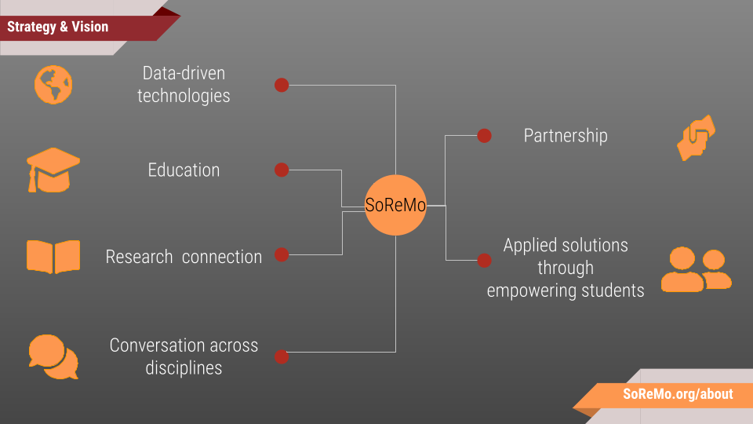

SoReMo’s place in higher education: our vision

Finally, to close out their projects, Fellows are required to write a technical report. This publication showcases those reports. Each report has been reviewed by a group of peers and faculty, and has been revised at least once.

> The process mimics exactly what happens in formal academic publishing. But the authors retain copyright of their technical reports and may choose to submit them or build on them for future projects or publications.

## More information

Our [homepage](https://www.soremo.org) has additional information about the initiative, related events, past Fellow projects, and current and upcoming opportunities to get involved.

# Acknowledgements

Spring 2026 projects were financially supported by a generous gift from Dr. Michela Coffaro, in memory of Josephine Coffaro and Leah Betts, to support our collaboration with [Keeler Gardens](https://www.keelergardens.org/), and by a continued generous gift from Joel Krauss (MATH ’71), Board of Advisors Vice-Chair of the CoC Board of Advisors. Running this initiative in 2026 would not have been possible without the support of faculty advisers across multiple disciplines and the tireless advocacy of College of Computing Dean Nicole Beebe.

Our team is ever evolving and welcoming new contributors. We gratefully acknowledge everyone who has taken part in the Spring 2026 SoReMo Forum in any form, all the faculty and advisers and external collaborators who have helped the Fellows complete their projects, and the community partners, including the St. James Food Pantry and the Hyde Park School of Dance, who opened their doors and trusted students with real problems.

The anonymous referees, students, faculty, and outside experts, were instrumental in evaluating and improving the technical reports. We as editors are grateful for their time and service.

Claude Cowork (Anthropic) was used to assist in drafting and editing this editorial.

[^1]: Contact SP
[^2]: Contact GP